# ade12変異株におけるAde4顆粒形成の観察

MT

2023-03-15

# 1 この事例で扱うデータと統計

**カテゴリ変数**：`strain`（wt, ade12∆）, `condition`（mock, +adenine, +hypoxanthine）  
**数値変数**： 顆粒を持つ細胞の割合（%）:`pct_foci_cell`  
**グラフ**：棒グラフ（平均） + エラーバー（1SD） + ドットプロット（各データポイント）  
**統計**：Shapiro-Wilk検定による正規性の検証、Kruskal-Wallis検定によるノンパラメトリックな1元配置分散分析、Steelの多重検定（ノンパラメトリック）

# 2 データの取得と読み込み

Ade12の遺伝子破壊株におけるAde4顆粒形成を観察、野生株と顆粒形成効率を比較する。蛍光顕微鏡観察後、画像処理により顆粒を持つ細胞の割合を計測し、csvファイルで出力。

```r
library(pacman)
# パッケージをまとめてロード
p_load(tidyverse, openxlsx, readxl, ggtext, multcomp, ggsignif, knitr, nparcomp, rstatix, dunn.test)
```

3/15, 3/16, 3/17のfoci_stat.csvが入っているフォルダを指定。

```r
import_file_path <- "foci_stat_file"
csv_list<- list.files(import_file_path, full.names = T, recursive = T, pattern = "*.csv")
```

`spply()`を使い、ファイル名リストから全てのファイルを一括で読み込み、データフレームのリストを作成。さらに`bind_rows()`でデータフレームを縦に連結して１つにする。

```r
foci_stat <- csv_list %>%
  sapply(., read.csv, header =T, sep = ",", stringsAsFactors = F, simplify = F) %>%
  bind_rows()
```

実験日の違いを示す変数`exp`を作っておく。file名に重複があるので、expと組み合わせて固有のfile名にする。

```r
foci_stat <- foci_stat %>% mutate(exp = case_when(
  str_detect(date, "0315") ~ "exp1",
  str_detect(date, "0316") ~ "exp2",
  str_detect(date, "0317") ~ "exp3"))
foci_stat <- foci_stat %>% mutate(id = paste(file_name,exp, sep = "_"))
```

使用した細胞の遺伝型を示す、変数`strain`を作る。`str_detect()`は`tidyverse`群の中の`stringr`パッケージ中の関数、指定したベクトル中から正規表現で一致するものをTRUE/FALSEで返す

```r
foci_stat <-
  foci_stat %>%
  mutate(strain =case_when(
# ID中に"wt"が含まれていればTRUE, case_whenで条件を並列に書ける
    str_detect(id, "wt") ~ "wt",
    str_detect(id, "ade12") ~ "ade12∆"))
```

同様に処理条件を表す変数`condition`を作る。

```r
foci_stat <-
  foci_stat %>%
  mutate(condition =case_when(
    str_detect(id, "scade") ~ "+adenine",
    str_detect(id, "schyp") ~ "+hypoxanthine",
    str_detect(id, "sc") ~ "mock")
  )
```

`condition`と`strain`をfactor型にして、レベル順を規定する

```r
foci_stat$condition <- factor(foci_stat$condition, levels=c("mock","+adenine","+hypoxanthine"))
foci_stat$strain <- factor(foci_stat$strain, levels = c("wt", "ade12∆"))
foci_stat <- as_tibble(foci_stat)
foci_stat
```

```
## # A tibble: 206 × 12
##        X file_name  total_cell_number foci_cell pct_foci_cell prominence defocus
##    <int> <chr>                  <int>     <int>         <dbl>      <int> <lgl>
##  1     1 Ade4-GFP_…               116        91          78.4       2000 NA
##  2     2 Ade4-GFP_…               129        92          71.3       2000 NA
##  3     3 Ade4-GFP_…               142       108          76.1       2000 NA
##  4     4 Ade4-GFP_…               133        84          63.2       2000 NA
##  5     5 Ade4-GFP_…               157       115          73.2       2000 NA
##  6     6 Ade4-GFP_…               134        90          67.2       2000 NA
##  7     7 Ade4-GFP_…               161       105          65.2       2000 NA
##  8     8 Ade4-GFP_…               140        81          57.9       2000 NA
##  9     9 Ade4-GFP_…               127        75          59.1       2000 NA
## 10    10 Ade4-GFP_…               126        69          54.8       2000 NA
## # ℹ 196 more rows
## # ℹ 5 more variables: date <int>, exp <chr>, id <chr>, strain <fct>,
## #   condition <fct>
```

# 3 データの集計

視野内で顆粒を持つ細胞の割合（%）を表す変数`pct_foci_cell`の平均とSDを求める。また1ｘSDに相当するerror barを書くための範囲を設定。結果をExcelファイルとして保存。

```r
# strainとconditionでグループ分けしてfociを持つ細胞の割合（pct_foci_cell）の平均とSDを計算
mean_sd <-
  foci_stat %>%
  group_by(strain, condition) %>%
  summarise(
    mean_pct = mean(pct_foci_cell),
    sd_pct = sd(pct_foci_cell), N=n())
# Define the top and bottom of the errorbars
limits <- aes(ymax = mean_pct + sd_pct, ymin = mean_pct - sd_pct)

mean_sd %>% write.xlsx("230315-17_ade12_mean_sd.xlsx", colNames = T, sheetName = "230315")
```

# 4 正規性の検証

データが正規分布に従っているかどうか、Shapiro-Wilk検定でデータの正規性を検証する。

```r
# strainとconditionの種類をベクトルとして取り出しておく
strains <- levels(foci_stat$strain)
conditions <- levels(foci_stat$condition)

# あるstrainの値に対応するpct_foci_cellの値の分布をshapiro.test()で検定するための関数を作成
swt <- function(astrain, cond) {foci_stat %>%
  filter(strain == astrain & condition == cond) %>%
  dplyr::select(pct_foci_cell) %>%
  as_vector() %>%
  shapiro.test()}
swt("wt", "mock") # 関数のテスト
```

```
##
##  Shapiro-Wilk normality test
##
## data:  .
## W = 0.92117, p-value = 0.02535
```

`strain`と`condition`の組み合わせを`expand.grid()`で求め、データフレーム`comb`として出力。名前の組も変数`combination`として作成しておく。

```r
comb <- expand.grid(strains, conditions) %>%
  rename(strain = Var1, condition = Var2) %>%
  mutate(combination = paste(strain, condition, sep = "_"))
comb
```

```
##   strain     condition          combination
## 1     wt          mock              wt_mock
## 2 ade12∆          mock          ade12∆_mock
## 3     wt      +adenine          wt_+adenine
## 4 ade12∆      +adenine      ade12∆_+adenine
## 5     wt +hypoxanthine     wt_+hypoxanthine
## 6 ade12∆ +hypoxanthine ade12∆_+hypoxanthine
```

データフレームを入力としてShapiro-Wilk検定を行う関数`swt2`を作成、組み合わせ全体に対して検定を行い、結果をリストに格納。

```r
swt2 <- function(df) {foci_stat %>%
  filter(strain == df[["strain"]] &  # strainを指定
        condition == df[["condition"]]) %>%  # conditionを指定
    # group_by()でグループ化している場合は解除してselect()
    # ungroup() %>%
  dplyr::select(pct_foci_cell) %>%
  as_vector() %>% # ベクトル型に直す
  shapiro_test()}

res_swt <- apply(comb, 1, swt2)  # データフレームcombの各行ごとに関数を適用
names(res_swt) <- comb$combination  # リストの要素と組み合わせを対応付ける

sink("res_swt.txt") # res_swtをテキストファイルに保存
res_swt
```

```
## $wt_mock
## # A tibble: 1 × 3
##   variable statistic p.value
##   <chr>        <dbl>   <dbl>
## 1 .            0.921  0.0254
##
## $`ade12∆_mock`
## # A tibble: 1 × 3
##   variable statistic p.value
##   <chr>        <dbl>   <dbl>
## 1 .            0.971   0.351
##
## $`wt_+adenine`
## # A tibble: 1 × 3
##   variable statistic p.value
##   <chr>        <dbl>   <dbl>
## 1 .            0.897  0.0183
##
## $`ade12∆_+adenine`
## # A tibble: 1 × 3
##   variable statistic   p.value
##   <chr>        <dbl>     <dbl>
## 1 .            0.842 0.0000390
##
## $`wt_+hypoxanthine`
## # A tibble: 1 × 3
##   variable statistic p.value
##   <chr>        <dbl>   <dbl>
## 1 .            0.927  0.0823
##
## $`ade12∆_+hypoxanthine`
## # A tibble: 1 × 3
##   variable statistic p.value
##   <chr>        <dbl>   <dbl>
## 1 .            0.919 0.00544
```

```r
sink()
```

ほぼ全ての組み合わせでp<0.05なので、データが正規分布に従っているとは言えない。従って、ノンパラメトリックな手法で解析する。`strain`と`condition`の2つのカテゴリ変数があるため、2つの1元配置分散分析と捉えるか、2元配置分散分析と捉えるかで検定手法が変わる。

組み合わせの計算の別法。`dplyr::expand_grid()`を使うと、オブジェクト名がそのまま変数名になるので名前を付け直す必要が無い。

```r
comb2 <-
  expand_grid(strains, conditions) %>%
  mutate(combination = paste(strains, conditions, sep = "_"))
comb2
```

```
## # A tibble: 6 × 3
##   strains conditions    combination
##   <chr>   <chr>         <chr>
## 1 wt      mock          wt_mock
## 2 wt      +adenine      wt_+adenine
## 3 wt      +hypoxanthine wt_+hypoxanthine
## 4 ade12∆  mock          ade12∆_mock
## 5 ade12∆  +adenine      ade12∆_+adenine
## 6 ade12∆  +hypoxanthine ade12∆_+hypoxanthine
```

関数をデータフレーム入力用に変更せず、`swt()`をそのまま使う方法。  
`map2`で2つの変数`strains`, `conditions`を`swt`に入力、結果を変数`swt_res`に格納。

```r
comb2 <-
  comb2 %>%
  mutate(swt_res = map2(strains, conditions, swt))
```

さらに`swt_res`からp値だけを抽出する。`rowwise()`にすることで、リストである`swt_res`の要素を指定できる。

```r
comb2 <-
comb2 %>%
  rowwise() %>%
  mutate(pval = swt_res$p.value)
comb2
```

```
## # A tibble: 6 × 5
## # Rowwise:
##   strains conditions    combination          swt_res      pval
##   <chr>   <chr>         <chr>                <list>      <dbl>
## 1 wt      mock          wt_mock              <htest> 0.0254
## 2 wt      +adenine      wt_+adenine          <htest> 0.0183
## 3 wt      +hypoxanthine wt_+hypoxanthine     <htest> 0.0823
## 4 ade12∆  mock          ade12∆_mock          <htest> 0.351
## 5 ade12∆  +adenine      ade12∆_+adenine      <htest> 0.0000390
## 6 ade12∆  +hypoxanthine ade12∆_+hypoxanthine <htest> 0.00544
```

## 4.1 1元配置分散分析と捉える場合

`strain`を`pct_foci_cell`に影響を与えるカテゴリ変数とせずに、`condition`だけをカテゴリ変数とすれば、ノンパラメトリックな1元配置分散分析になり、Kruskal-Wallis検定が利用できる。

```r
aov_kw_wt <- foci_stat %>%
  filter(strain == "wt") %>%  # wtのデータを抽出
  kruskal_test(pct_foci_cell ~ condition)
# aov_kw_wt  # p<0.05よりグループ間に違いがあることを示唆

aov_kw_ade12 <- foci_stat %>%
  filter(strain == "ade12∆") %>%  # ade12∆のデータを抽出
  kruskal_test(pct_foci_cell ~ condition)
# aov_kw_ade12  # p<0.05よりグループ間に違いがあることを示唆

sink("res_aov_kw.txt")  # 結果を保存
aov_kw_wt
```

```
## # A tibble: 1 × 6
##   .y.               n statistic    df        p method
## * <chr>         <int>     <dbl> <int>    <dbl> <chr>
## 1 pct_foci_cell    79      57.7     2 3.03e-13 Kruskal-Wallis
```

```r
aov_kw_ade12
```

```
## # A tibble: 1 × 6
##   .y.               n statistic    df        p method
## * <chr>         <int>     <dbl> <int>    <dbl> <chr>
## 1 pct_foci_cell   127      83.4     2 7.73e-19 Kruskal-Wallis
```

```r
sink()
```

（参考）線形モデルを仮定した1元配置分散分析

```r
lm_model_wt <- foci_stat %>%
  filter(strain == "wt") %>%
  lm(pct_foci_cell ~ condition, data = .)
# autoplot(lm_model_wt, smooth.colour = NA)
anova(lm_model_wt)
```

```
## Analysis of Variance Table
##
## Response: pct_foci_cell
##           Df Sum Sq Mean Sq F value    Pr(>F)
## condition  2 108150   54075  5416.9 < 2.2e-16 ***
## Residuals 76    759      10
## ---
## Signif. codes:  0 '***' 0.001 '**' 0.01 '*' 0.05 '.' 0.1 ' ' 1
```

```r
summary(lm_model_wt)
```

```
##
## Call:
## lm(formula = pct_foci_cell ~ condition, data = .)
##
## Residuals:
##     Min      1Q  Median      3Q     Max
## -12.071  -0.255   0.026   0.514   6.204
##
## Coefficients:
##                        Estimate Std. Error t value Pr(>|t|)
## (Intercept)             76.1487     0.5675  134.19   <2e-16 ***
## condition+adenine      -75.8937     0.8591  -88.35   <2e-16 ***
## condition+hypoxanthine -75.6558     0.8591  -88.07   <2e-16 ***
## ---
## Signif. codes:  0 '***' 0.001 '**' 0.01 '*' 0.05 '.' 0.1 ' ' 1
##
## Residual standard error: 3.16 on 76 degrees of freedom
## Multiple R-squared:  0.993,  Adjusted R-squared:  0.9929
## F-statistic:  5417 on 2 and 76 DF,  p-value: < 2.2e-16
```

```r
lm_model_ade12 <- foci_stat %>%
  filter(strain == "ade12∆") %>%
  lm(pct_foci_cell ~ condition, data = .)
# autoplot(lm_model_ade12, smooth.colour = NA)
anova(lm_model_ade12)
```

```
## Analysis of Variance Table
##
## Response: pct_foci_cell
##            Df Sum Sq Mean Sq F value    Pr(>F)
## condition   2  37995 18997.7  116.97 < 2.2e-16 ***
## Residuals 124  20140   162.4
## ---
## Signif. codes:  0 '***' 0.001 '**' 0.01 '*' 0.05 '.' 0.1 ' ' 1
```

```r
summary(lm_model_ade12)
```

```
##
## Call:
## lm(formula = pct_foci_cell ~ condition, data = .)
##
## Residuals:
##      Min       1Q   Median       3Q      Max
## -30.4316  -4.1508   0.9213   5.2937  26.4694
##
## Coefficients:
##                        Estimate Std. Error t value Pr(>|t|)
## (Intercept)              74.904      1.944  38.541   <2e-16 ***
## condition+adenine       -36.156      2.765 -13.077   <2e-16 ***
## condition+hypoxanthine    1.202      2.765   0.435    0.665
## ---
## Signif. codes:  0 '***' 0.001 '**' 0.01 '*' 0.05 '.' 0.1 ' ' 1
##
## Residual standard error: 12.74 on 124 degrees of freedom
## Multiple R-squared:  0.6536, Adjusted R-squared:  0.648
## F-statistic:   117 on 2 and 124 DF,  p-value: < 2.2e-16
```

Dunnett法のノンパラメトリック版としてSteel testで多重比較する。nparcompパッケージのnparcomp()を使用。ここで得られたp値をグラフにアノテーションする。

```r
res_st_wt <- foci_stat %>%
  filter(strain == "wt") %>%
  nparcomp(pct_foci_cell ~ condition, data = .,
            asy.method = "mult.t", type = "Dunnett",
    # Dunnettの場合はcontrolで基準となるグループを指定
           control = "mock", alternative = "two.sided", info = FALSE)

res_st_ade12 <- foci_stat %>%
  filter(strain == "ade12∆") %>%
  nparcomp(pct_foci_cell ~ condition, data = .,
            asy.method = "mult.t", type = "Dunnett",
           control = "mock", alternative = "two.sided", info = FALSE)

sink("res_steel_test_wt.txt")
summary(res_st_wt)
```

```
##
##  #------------Nonparametric Multiple Comparisons for relative contrast effects----------#
##
##  - Alternative Hypothesis:  True relative contrast effect p is not equal to 1/2
##  - Estimation Method: Global Pseudo ranks
##  - Type of Contrast : Dunnett
##  - Confidence Level: 95 %
##  - Method = Multi - T with 1000 DF
##
##  - Estimation Method: Pairwise rankings
##
##  #---------------------------Interpretation--------------------------------------------#
##  p(a,b) > 1/2 : b tends to be larger than a
##  #-------------------------------------------------------------------------------------#
##
##  #----Data Info-------------------------------------------------------------------------#
##          Sample Size
## 1          mock   31
## 2      +adenine   24
## 3 +hypoxanthine   24
##
##  #----Contrast--------------------------------------------------------------------------#
##                      mock +adenine +hypoxanthine
## +adenine - mock        -1        1             0
## +hypoxanthine - mock   -1        0             1
##
##  #----Analysis--------------------------------------------------------------------------#
##                  Comparison Estimator Lower Upper Statistic p.Value
## 1      p( mock , +adenine )     0.001     0 0.002 -1402.536       0
## 2 p( mock , +hypoxanthine )     0.001     0 0.002 -1402.536       0
##
##  #----Overall---------------------------------------------------------------------------#
##   Quantile p.Value
## 1 2.239697       0
##
##  #--------------------------------------------------------------------------------------#
```

```r
sink()
sink("res_steel_test_ade12.txt")
summary(res_st_ade12)
```

```
##
##  #------------Nonparametric Multiple Comparisons for relative contrast effects----------#
##
##  - Alternative Hypothesis:  True relative contrast effect p is not equal to 1/2
##  - Estimation Method: Global Pseudo ranks
##  - Type of Contrast : Dunnett
##  - Confidence Level: 95 %
##  - Method = Multi - T with 79 DF
##
##  - Estimation Method: Pairwise rankings
##
##  #---------------------------Interpretation--------------------------------------------#
##  p(a,b) > 1/2 : b tends to be larger than a
##  #-------------------------------------------------------------------------------------#
##
##  #----Data Info-------------------------------------------------------------------------#
##          Sample Size
## 1          mock   43
## 2      +adenine   42
## 3 +hypoxanthine   42
##
##  #----Contrast--------------------------------------------------------------------------#
##                      mock +adenine +hypoxanthine
## +adenine - mock        -1        1             0
## +hypoxanthine - mock   -1        0             1
##
##  #----Analysis--------------------------------------------------------------------------#
##                  Comparison Estimator  Lower Upper   Statistic   p.Value
## 1      p( mock , +adenine )     0.004 -0.004 0.013 -138.143526 0.0000000
## 2 p( mock , +hypoxanthine )     0.575  0.430 0.720    1.180539 0.4188057
##
##  #----Overall---------------------------------------------------------------------------#
##   Quantile p.Value
## 1 2.274935       0
##
##  #--------------------------------------------------------------------------------------#
```

```r
sink()
```

## 4.2 2元配置分散分析と捉える場合

前述のKruskal-Wallis検定は1元配置分散分析用であり、2元配置分散分析には適用できない。一般的にノンパラメトリックな2元配置分散分析を直接解析する手法は無い。`foci_stat`の平均値を取った`mean_sd`ならばFriedman検定が適用できる。p>0.05となり`pct_foci_cell`の値は`condition`や`strain`の種類に依存しないという帰無仮説は棄却されない。

```r
res_fried <- mean_sd %>% friedman.test(data=., mean_pct ~ condition | strain)
res_fried
```

```
##
##  Friedman rank sum test
##
## data:  mean_pct and condition and strain
## Friedman chi-squared = 3, df = 2, p-value = 0.2231
```

（参考）線形モデルを仮定した2元配置分散分析

```r
model_ade12 <- foci_stat %>% lm(pct_foci_cell ~ strain * condition, data=.)
# ggplot2::autoplot(model_ade12, smooth.colour =NA)
anova(model_ade12)
```

```
## Analysis of Variance Table
##
## Response: pct_foci_cell
##                   Df Sum Sq Mean Sq F value    Pr(>F)
## strain             1  53799   53799  514.85 < 2.2e-16 ***
## condition          2  97113   48557  464.68 < 2.2e-16 ***
## strain:condition   2  49032   24516  234.62 < 2.2e-16 ***
## Residuals        200  20899     104
## ---
## Signif. codes:  0 '***' 0.001 '**' 0.01 '*' 0.05 '.' 0.1 ' ' 1
```

```r
summary(model_ade12)
```

```
##
## Call:
## lm(formula = pct_foci_cell ~ strain * condition, data = .)
##
## Residuals:
##      Min       1Q   Median       3Q      Max
## -30.4316  -1.7841   0.1185   3.3990  26.4694
##
## Coefficients:
##                                     Estimate Std. Error t value Pr(>|t|)
## (Intercept)                           76.149      1.836  41.476   <2e-16 ***
## strainade12∆                          -1.245      2.409  -0.517    0.606
## condition+adenine                    -75.894      2.779 -27.306   <2e-16 ***
## condition+hypoxanthine               -75.656      2.779 -27.221   <2e-16 ***
## strainade12∆:condition+adenine        39.738      3.556  11.176   <2e-16 ***
## strainade12∆:condition+hypoxanthine   76.858      3.556  21.616   <2e-16 ***
## ---
## Signif. codes:  0 '***' 0.001 '**' 0.01 '*' 0.05 '.' 0.1 ' ' 1
##
## Residual standard error: 10.22 on 200 degrees of freedom
## Multiple R-squared:  0.9054, Adjusted R-squared:  0.903
## F-statistic: 382.7 on 5 and 200 DF,  p-value: < 2.2e-16
```

# 5 データの可視化

顆粒を持つ細胞の割合の平均値を棒グラフで、1SDをエラーバーで描画。個々のデータ点もプロット。検定の結果も表示。

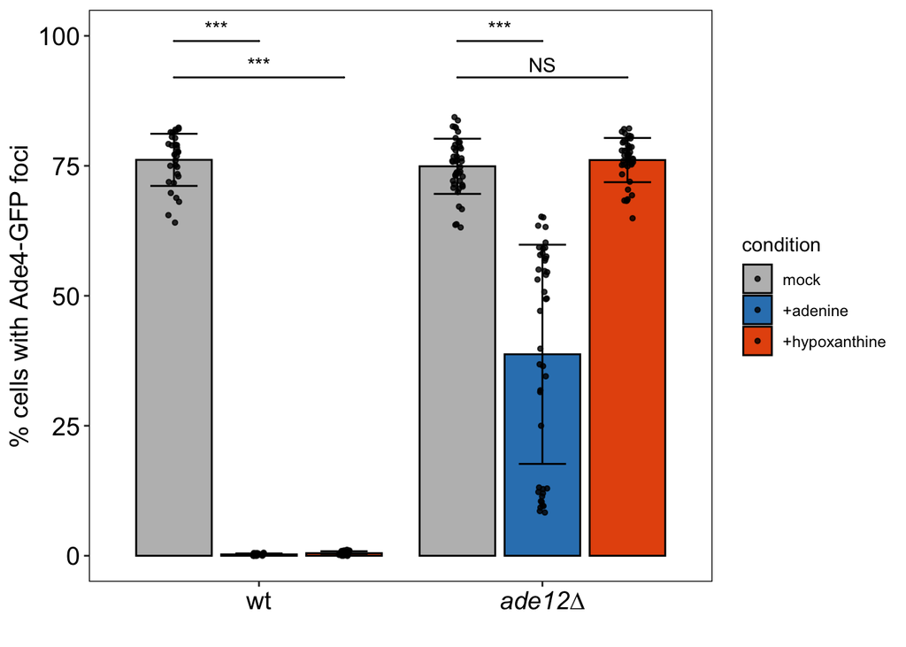

```r
# p値を手動でアノテーションするために必要なオブジェクト
annot1 = c("***", "***", "***", "NS")
y_position = c(99,92,99,92)
xmin = c(0.7, 0.7, 1.7,1.7)
xmax = c(1, 1.3, 2,2.3)

plot1 <- mean_sd %>%
  ggplot(aes(x= strain, y=mean_pct, fill=condition))+
  geom_bar(stat="identity", color="black", width = 0.8, position = position_dodge(width = 0.9))+
  geom_errorbar(limits, width = 0.5, position = position_dodge(width=0.9))+
  geom_jitter(foci_stat, mapping=aes(x=strain, y= pct_foci_cell),size = 1,
              alpha=0.8, position = position_jitterdodge(jitter.width = 0.1, jitter.height = 0, dodge.width = .9))+
  geom_signif(xmin = xmin, xmax  =xmax, y_position =y_position, annotations = annot1, tip_length = 0.00)+
  scale_fill_manual(values = c('#bdbdbd','#3182bd',"#e6550d")) + # fillの色を手動で指定
  # x軸（strain）の順番を指定する, ggtextを使用すると*で囲むと斜体になる、labelsを指定
  scale_x_discrete(limits = c("wt", "ade12∆"), labels =c("wt", "*ade12∆*")) +
  ylab("% cells with Ade4-GFP foci") +
  xlab("")+
  ylim(0,100)+
  theme( axis.title.y = element_text(size=14), axis.text.y = element_text(size=14,color = "black"),
         # ggtextを使用する場合はelement_markdownで指定
         axis.text.x = element_markdown(size = 14,colour = "black")
         #,legend.position = "none" #凡例を消す
         ,panel.border = element_rect(fill = NA, linewidth = 0.5) # パネルを枠で囲む
         ,panel.background = element_blank()) #背景を白にする
plot1
```